# Diversity Activity

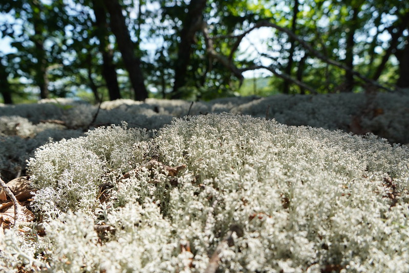

## Overview

In this activity, we will be examining diversity in the Sonoran desert bark beetle, *Araptus attenuatus*, included in the `gstudio` library.

```r
library( tidyverse )
library( gstudio )
data( arapat )
summary( arapat )
```

```
      Species      Cluster      Population        ID         Latitude
 Cape     : 75   CBP-C :150   32     : 19   101_10A:  1   Min.   :23.08
 Mainland : 36   NBP-C : 84   75     : 11   101_1A :  1   1st Qu.:24.59
 Peninsula:252   SBP-C : 18   Const  : 11   101_2A :  1   Median :26.25
                 SCBP-A: 75   12     : 10   101_3A :  1   Mean   :26.25
                 SON-B : 36   153    : 10   101_4A :  1   3rd Qu.:27.53
                              157    : 10   101_5A :  1   Max.   :29.33
                              (Other):292   (Other):357
   Longitude          LTRS          WNT            EN           EF
 Min.   :-114.3   01:01 :147   03:03  :108   01:01  :225   01:01 :219
 1st Qu.:-113.0   01:02 : 86   01:01  : 82   01:02  : 52   01:02 : 52
 Median :-111.5   02:02 :130   01:03  : 77   02:02  : 38   02:02 : 90
 Mean   :-111.7                02:02  : 62   03:03  : 22   NA's  :  2
 3rd Qu.:-110.5                03:04  :  8   01:03  :  7
 Max.   :-109.1                (Other): 15   (Other): 16
                               NA's   : 11   NA's   :  3
     ZMP           AML           ATPS          MP20
 01:01 : 46   08:08  : 51   05:05  :155   05:07  : 64
 01:02 : 51   07:07  : 42   03:03  : 69   07:07  : 53
 02:02 :233   07:08  : 42   09:09  : 66   18:18  : 52
 NA's  : 33   04:04  : 41   02:02  : 30   05:05  : 48
              07:09  : 22   07:09  : 14   05:06  : 22
              (Other):142   08:08  :  9   (Other):119
              NA's   : 23   (Other): 20   NA's   :  5
```

## Activity Questions

1. Create a `leaflet` map showing the levels of effective allelic diversity ($A_e$) for Populations for loci $LTRS$, $WNT$, and $EN$.

```r
library( leaflet )
library( leaflet.minicharts )

arapat %>%
  select( Population, LTRS, WNT, EN ) %>%
  genetic_diversity( mode="Ae",
                     stratum = "Population") %>%
  spread( Locus, Ae) %>%
  left_join(  strata_coordinates(arapat) ) -> diversity
leaflet() %>%
  addProviderTiles( providers$Esri.WorldTerrain ) %>%
  addMinicharts( diversity$Longitude, diversity$Latitude,
                 chartdata =  diversity %>% select( LTRS, WNT, EN ),
                 colorPalette = c("#3093e5", "#fcba50", "#a0d9e8"),
                 width=45,
                 height=45)
```

[interactive chart not shown]

2. Estimate effective allelic diversity for all populations of the individuals where *Species == Peninsula* at the locus `MP20`. Is there the same indication of “Allele Surfing” in the beetle as shown for its host plant? How do you interpret this pattern?

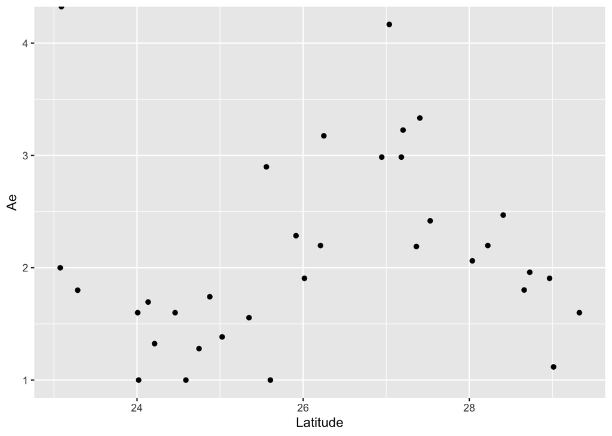

```r
arapat %>%
  filter( Species == "Peninsula" ) %>%
  select( Population, MP20 ) %>%
  genetic_diversity( stratum = "Population" )  %>%
  left_join( strata_coordinates(arapat), by="Stratum") %>%
  select( Stratum, Latitude, Ae) %>%
  ggplot( aes(Latitude, Ae) ) +
  geom_point()
```

3. Is there more effective allelic diversity in the `Cape` or `Peninsula` groupings?

```r
cape <- arapat %>% filter(Species == "Cape") %>% droplevels()
n.cape <- nrow( cape )
n.cape
```

```
[1] 75
```

```r
peninsula <- arapat %>% filter( Species == "Peninsula" ) %>% droplevels()
n.peninsula <- nrow( peninsula )
n.peninsula
```

```
[1] 252
```

*So, we’ll want to subsample `peninsula` in sizes equal to 75 and do a rarefaction for each locus. I’ll demonstrate with one of the loci, but you’d probably want to do all of them and then summarize them in a table or something.*

```r
peninsula.mp20 <- rarefaction( peninsula$MP20, size = n.cape, mode = "Ae", nperm = 999)
cape.mp20 <- genetic_diversity(cape$MP20)
cape.mp20
```

|  | Locus | Ae |
| --- | --- | --- |
| 1 | Locus | 1.582056 |

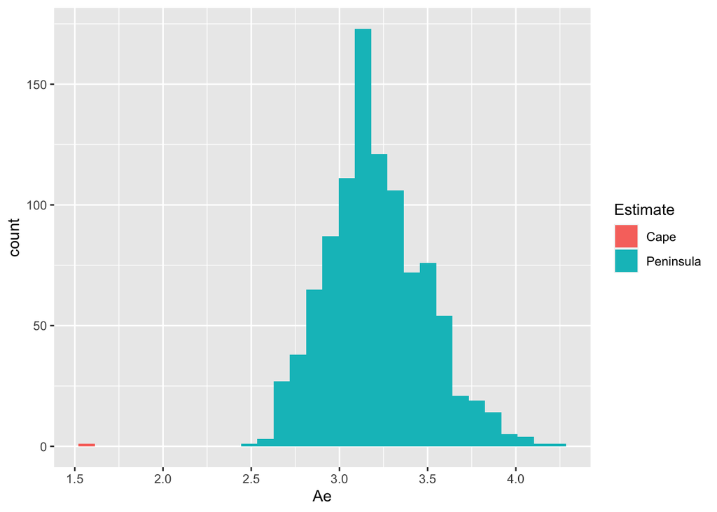

```r
Ae <- data.frame( Ae = c( cape.mp20$Ae[1], peninsula.mp20 ),
                  Estimate = factor( c("Cape",rep("Peninsula",999))) )
ggplot( Ae, aes(Ae, fill=Estimate) ) +
  geom_histogram()
```

*It looks like there is a lot less diversity in the Cape when compared to the rest of the peninsula*

4. Is there a correlation between genetic effective allelic diversity ($A_e$) and genotypic diversity ($H_e$) in these data? Do you expect there to be one? Why?